# Francesco Denti

"The writer Umberto Eco belongs to that small class of scholars who are encyclopedic, insightful, and nondull.  
He is the owner of a large personal library (containing thirty thousand books), and separates visitors into two categories: those who react with “Wow! Signore, professore dottore Eco, what a library you have ! How many of these books have you read?” and the others - a very small minority - who get the point that a private library is not an ego-boosting appendage but a research tool.  
Read books are far less valuable than unread ones."  
The Black Swan - N. N. Taleb

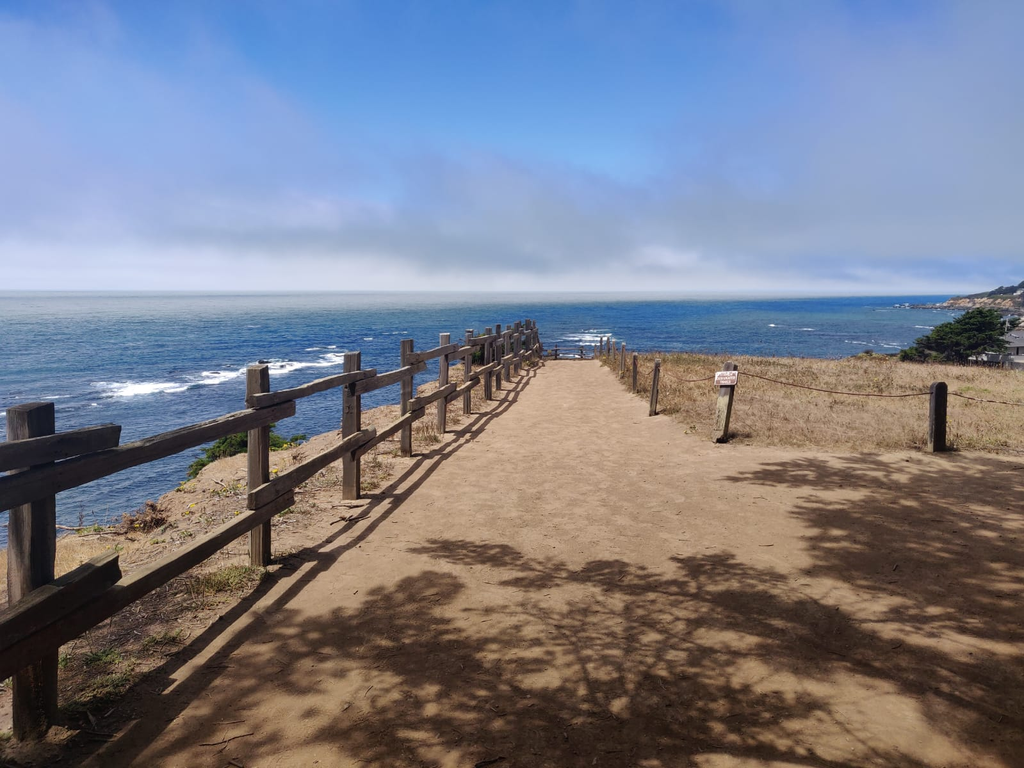

### About (the academic) me

"Cammino in mezzo agli altri, tutti più o meno uguali  
E canto nella testa un poco di Brunori SAS  
Faccio parte anch’io di quest’aurea mediocritas.  
E vado ricercando medie senza varianza, un pò di stabilità  
Male non fa"  
Romastino - Translation

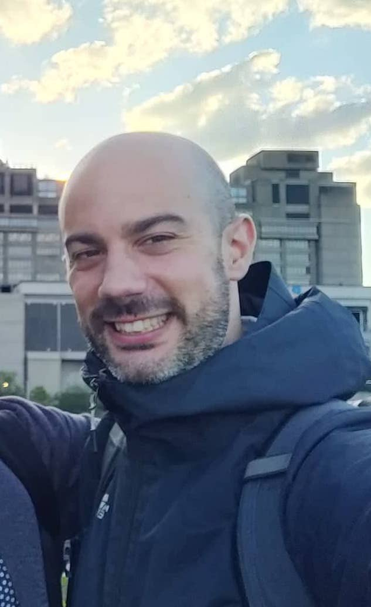

I am an Assistant Professor (RtdB) at the [Department of Statistics of University of Padua](https://www.stat.unipd.it).

Previously, I held the role of Assistant Professor (RtdA) at the [Department of Statistics of Università Cattolica del Sacro Cuore - Milan](https://dipartimenti.unicatt.it/scienze_statistiche).  
Prior to that, I spent two years as a Postdoctoral Scholar at the [Department of Statistics of Univerisity of California - Irvine](https://www.stat.uci.edu/) (UCI), working under the supervision of Professor [Babak Shahbaba](https://www.ics.uci.edu/~babaks/).

I obtained a Ph.D. in Statistics at University of Milan - Bicocca and Università della Svizzera italiana (joint program, awarded with honors) working with Professor [Antonietta Mira](https://search.usi.ch/en/people/f8960de6d60dd08a79b6c1eb20b7442b/mira-antonietta) and Professor [Michele Guindani](https://www.micheleguindani.info).

I am interested in Bayesian mixtures, Bayesian nonparametrics, model-based clustering, shrinkage priors, and dimensionality reduction.

### News and highlights

[2024/02/21] I joined the Department of Statistics at the University of Padua as a senior Assistant Professor (RtdB)

### Contacts

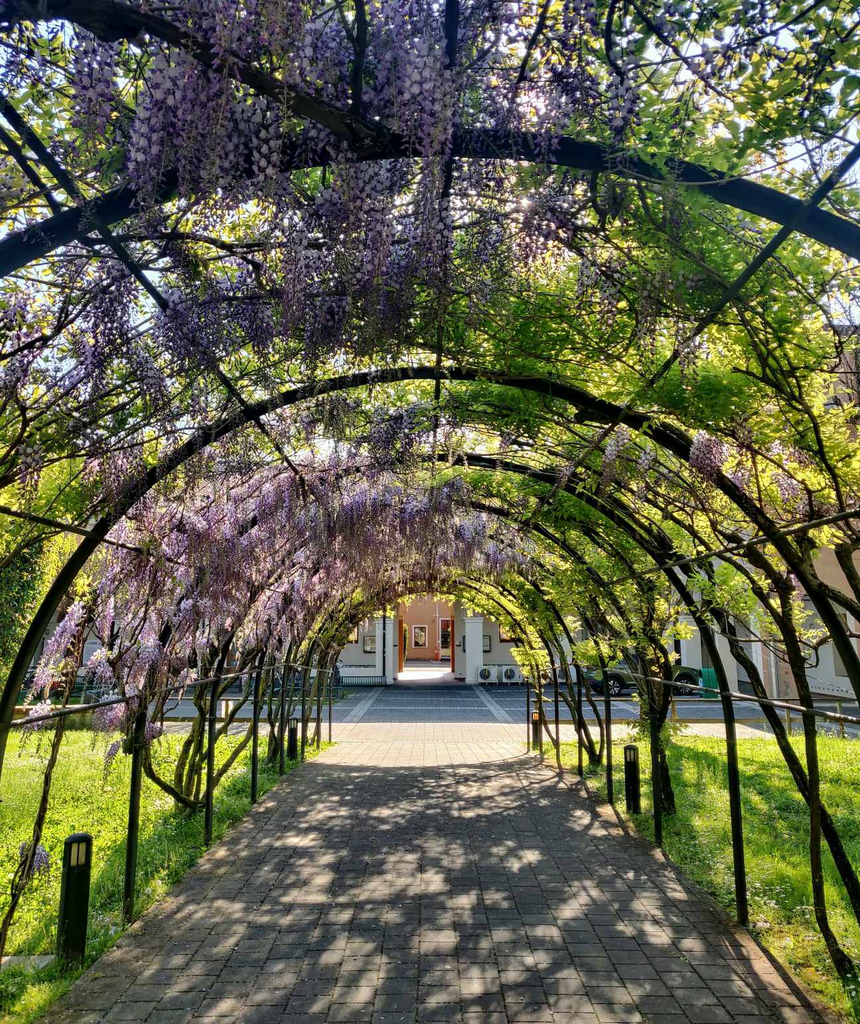

**Email**: francesco (dot) denti (at) unipd (dot) it  
**Office**: Room 151, Via Cesare Battisti 241, Padua  
[Department of Statistics of University of Padua](https://www.stat.unipd.it)